# Portfoliomanagement and Financial Analysis - Assignment 2

## Exercise 2: The mu/sigma diagram

For the 10 stocks in your sample, calculate mu and sigma for the entire and 3 subperiods. Plot all four combinations in a mu-sigma diagram.

Next, use the power of `tsibble` to calculate rolling/growing versions of mu and sigma (e.g. start with 6 months of data). Try to plot the changing mu and sigma via an animation using `gganimate` (see [here](https://www.datanovia.com/en/blog/gganimate-how-to-create-plots-with-beautiful-animation-in-r/)).

```r
mult_stocks <- tq_get(c("AMZN","YUM","PG","JNJ","MSFT","AXP","BAC","FDX","F","HD"),get = "stock.prices",from = "2000-01-01", to = "2020-09-24")
mult_Ra <- c("AMZN","YUM","PG","JNJ","MSFT","AXP","BAC","FDX","F","HD") %>% tq_get(get= "stock.prices", from ="2000-01-01", to = "2020-09-24") %>% group_by(symbol) %>% tq_transmute(select = adjusted, mutate_fun = periodReturn, period ="yearly",col_rename = "Mu")
mult_sigma <- c("AMZN","YUM","PG","JNJ","MSFT","AXP","BAC","FDX","F","HD") %>% tq_get(get= "stock.prices", from ="2000-01-01", to = "2020-09-24") %>% group_by(symbol) %>% tq_transmute(select = adjusted, mutate_fun = periodReturn, period ="yearly",col_rename = "Sigma")
```

```r
#In order to stack them to together makes a little bit easier.
mu_Ra <- aggregate(mult_Ra[3:3],list(mult_Ra$symbol),mean)
sigma_Ra <- aggregate(mult_sigma[3:3],list(mult_Ra$symbol),mean.stderr)
mult_musig <- left_join(mu_Ra, sigma_Ra, by = "Group.1")
```

```r
ggplot(mult_musig,aes(x=Sigma, y=Mu,label=Group.1)) + geom_point(alpha =0.6) + coord_fixed() + scale_x_log10() + scale_y_log10() + geom_text(aes(label=Group.1),hjust=0, vjust=0)
```

```r
ggplot(mult_musig,aes(x=Sigma, y=Mu)) + geom_point(alpha =0.6) + coord_fixed() + scale_x_log10() + scale_y_log10() + stat_smooth(method = "lm",col = "#C42126",se = FALSE, size=1)
```

```r
mult_period <- tq_get(c("AMZN","YUM","PG","JNJ","MSFT","AXP","BAC","FDX","F","HD"),get = "stock.prices",from = "2005-01-01", to = "2020-09-24")
mult_Ra_period <- c("AMZN","YUM","PG","JNJ","MSFT","AXP","BAC","FDX","F","HD") %>% tq_get(get= "stock.prices", from ="2005-01-01", to = "2020-09-24") %>% group_by(symbol) %>% tq_transmute(select = adjusted, mutate_fun = periodReturn, period ="yearly",col_rename = "Mu")
mult_sigma_period <- c("AMZN","YUM","PG","JNJ","MSFT","AXP","BAC","FDX","F","HD") %>% tq_get(get= "stock.prices", from ="2005-01-01", to = "2020-09-24") %>% group_by(symbol) %>% tq_transmute(select = adjusted, mutate_fun = periodReturn, period ="yearly",col_rename = "Sigma")

mu_Ra_period <- aggregate(mult_Ra_period[3:3],list(mult_Ra_period$symbol),mean)
sigma_Ra_period <- aggregate(mult_sigma_period[3:3],list(mult_Ra_period$symbol),mean.stderr)
mult_musig_period <- left_join(mu_Ra_period, sigma_Ra_period, by = "Group.1")

ggplot(mult_musig_period,aes(x=Sigma, y=Mu, lable = Group.1)) + geom_point(alpha =0.6) + coord_fixed() + scale_x_log10() + scale_y_log10() + geom_text(aes(label=Group.1),hjust=0, vjust=0)
```

```r
mult_period_nd <- tq_get(c("AMZN","YUM","PG","JNJ","MSFT","AXP","BAC","FDX","F","HD"),get = "stock.prices",from = "2010-01-01", to = "2020-09-24")
mult_Ra_period_nd <- c("AMZN","YUM","PG","JNJ","MSFT","AXP","BAC","FDX","F","HD") %>% tq_get(get= "stock.prices", from ="2010-01-01", to = "2020-09-24") %>% group_by(symbol) %>% tq_transmute(select = adjusted, mutate_fun = periodReturn, period ="yearly",col_rename = "Mu")
mult_sigma_period_nd <- c("AMZN","YUM","PG","JNJ","MSFT","AXP","BAC","FDX","F","HD") %>% tq_get(get= "stock.prices", from ="2010-01-01", to = "2020-09-24") %>% group_by(symbol) %>% tq_transmute(select = adjusted, mutate_fun = periodReturn, period ="yearly",col_rename = "Sigma")

mu_Ra_period_nd <- aggregate(mult_Ra_period_nd[3:3],list(mult_Ra_period_nd$symbol),mean)
sigma_Ra_period_nd <- aggregate(mult_sigma_period_nd[3:3],list(mult_Ra_period_nd$symbol),mean.stderr)
mult_musig_period_nd <- left_join(mu_Ra_period_nd, sigma_Ra_period_nd, by = "Group.1")

ggplot(mult_musig_period_nd,aes(x=Sigma, y=Mu, label=Group.1)) + geom_point(alpha =0.6) + coord_fixed() + scale_x_log10() + scale_y_log10() + geom_text(aes(label=Group.1),hjust=0, vjust=0)
```

```r
mult_period_rd <- tq_get(c("AMZN","YUM","PG","JNJ","MSFT","AXP","BAC","FDX","F","HD"),get = "stock.prices",from = "2002-01-01", to = "2020-09-24")
mult_Ra_period_rd <- c("AMZN","YUM","PG","JNJ","MSFT","AXP","BAC","FDX","F","HD") %>% tq_get(get= "stock.prices", from ="2002-01-01", to = "2020-09-24") %>% group_by(symbol) %>% tq_transmute(select = adjusted, mutate_fun = periodReturn, period ="yearly",col_rename = "Mu")
mult_sigma_period_rd <- c("AMZN","YUM","PG","JNJ","MSFT","AXP","BAC","FDX","F","HD") %>% tq_get(get= "stock.prices", from ="2002-01-01", to = "2020-09-24") %>% group_by(symbol) %>% tq_transmute(select = adjusted, mutate_fun = periodReturn, period ="yearly",col_rename = "Sigma")

mu_Ra_period_rd <- aggregate(mult_Ra_period_rd[3:3],list(mult_Ra_period_rd$symbol),mean)
sigma_Ra_period_rd <- aggregate(mult_sigma_period_rd[3:3],list(mult_Ra_period_rd$symbol),mean.stderr)
mult_musig_period_rd <- left_join(mu_Ra_period_rd, sigma_Ra_period_rd, by = "Group.1")

ggplot(mult_musig_period_rd,aes(x=Sigma, y=Mu, label=Group.1)) + geom_point(alpha =0.6) + coord_fixed() + scale_x_log10() + scale_y_log10() + geom_text(aes(label=Group.1),hjust=0, vjust=0)
```

```r
plot <- ggplot() + geom_point(data = mult_musig, aes(x=Sigma, y=Mu), color='green') + geom_point(data = mult_musig_period, aes(x=Sigma, y= Mu), color='red') + geom_point(data = mult_musig_period_nd ,aes(x = Sigma, y=Mu),color = 'blue') + geom_point(data= mult_musig_period_rd, aes(x=Sigma, y=Mu), color= 'orange')
plot
```

[output not shown]

Next, use the power of `tsibble` to calculate rolling/growing versions of mu and sigma (e.g. start with 6 months of data). Try to plot the changing mu and sigma via an animation using `gganimate` (see [here](https://www.datanovia.com/en/blog/gganimate-how-to-create-plots-with-beautiful-animation-in-r/)).

```r
pacman::p_load(gganimate,gifski,png,gapminder)
p <- ggplot(
gapminder,
aes(x = gdpPercap, y=lifeExp, size = pop, colour = country)
) +
geom_point(show.legend = FALSE, alpha = 0.7) +
scale_color_viridis_d() +
scale_size(range = c(2, 12)) +
scale_x_log10() +
labs(x = "GDP per capita", y = "Life expectancy")
p
p + transition_time(year) +
labs(title = "Year: {frame_time}")
```

```r
ov_mult_stocks <- tq_get(c("AMZN","YUM","PG","JNJ","MSFT","AXP","BAC","FDX","F","HD"),get = "stock.prices",from = "2020-01-01", to = "2020-09-24")
ov_try_periode <- c("AMZN","YUM","PG","JNJ","MSFT","AXP","BAC","FDX","F","HD") %>% tq_get(get= "stock.prices", from ="2020-01-01", to = "2020-09-24") %>% group_by(symbol) %>% tq_transmute(select = adjusted, mutate_fun = periodReturn, period ="daily",col_rename = "Return")
try_periode <- c("AMZN","YUM","PG","JNJ","MSFT","AXP","BAC","FDX","F","HD") %>% tq_get(get= "stock.prices", from ="2020-01-01", to = "2020-09-24") %>% group_by(symbol) %>% tq_transmute(select = adjusted, mutate_fun = periodReturn, period ="daily",col_rename = "Sigma")
```

```r
mean_try <- aggregate(ov_try_periode[3:3],list(ov_try_periode$symbol),mean)
names(mean_try)[names(mean_try) == "Group.1"] <- "symbol"
ov_pp <- left_join(ov_try_periode, mean_try)

sigma_try <- aggregate(try_periode [3:3],list(try_periode$symbol), mean.stderr )
names(sigma_try)[names(sigma_try) == "Group.1"] <- "symbol"
ov_fin <- left_join(ov_pp, sigma_try)
```

```r
p <- ggplot(
ov_fin,
aes(x = Sigma, y= Return, size = Return, colour = symbol)
) +
geom_point(show.legend = TRUE, alpha = 0.7) +
scale_color_viridis_d() +
scale_size(range = c(2, 12)) +
scale_x_log10() +
labs(x = "Risk", y = "Return")
p
p + transition_time(date) +
labs(title = "date: {frame_time}")
```

## Exercise 3: Rolling regressions

Perform static and rolling regressions of four of your assets (monthly data, yearly window) on the S&P500 as well as the three Fama-French Factors (Mkt.RF, SMB and HML). Visualize the changing alphas and betas over time. You can use [this example](https://www.business-science.io/code-tools/2017/04/04/tidyquant-0-5-0.html), but I would prefer a use of the `tsibble`-package.

```r
#### Rolling regressions ####
# a)
SP500_Stocks <- tq_index("S&P500")
```

```
Getting holdings for SP500
```

```r
# b) Download stock prices of stocks that had information at the 1.Jan.2000.

SP500_2000<-c("MSFT", "QCOM", "AXP", "GILD") %>% tq_get(get  = "stock.prices",from = "2000-01-01", to   = "2019-12-31")
```

Download Farma-French

```r
tempf <- tempfile(fileext = ".RData"); tempd <- tempdir(); temptxt <- tempfile(fileext = ".txt")
inputlist <- c("F-F_Research_Data_Factors")
# Now process only these files if they can be matched (download only)
FFdownload(exclude_daily=TRUE,tempdir=tempd,download=TRUE,download_only=FALSE,inputlist=inputlist)
```

```
Step 1: getting list of all the csv-zip-files!

Step 2: Downloading 1 zip-files

==================================================

Step 3: Start processing 1 csv-files
```

```r
tempf2 <- tempfile(fileext = ".RData"); tempd2 <- tempdir()
FFdownload(output_file = tempf2,tempdir = tempd2,exclude_daily = TRUE, download = TRUE, download_only=FALSE, listsave=temptxt)
```

```
Step 1: getting list of all the csv-zip-files!

Step 2: Downloading 193 zip-files

Step 3: Start processing 193 csv-files
```

[output not shown]

[output not shown]

[output not shown]

[output not shown]

[output not shown]

[output not shown]

[output not shown]

[output not shown]

[output not shown]

[output not shown]

[output not shown]

[output not shown]

[output not shown]

[output not shown]

[output not shown]

[output not shown]

[output not shown]

```r
load(tempf2)
ff<-FFdownload$x_Developed_3_Factors$monthly$Temp2
ff<-ff["2000/2019"]
sff<-timetk::tk_tbl(ff)
colnames(sff)[1]<-"date"
format(sff$date)
```

```
  [1] "Jan 2000" "Feb 2000" "Mar 2000" "Apr 2000" "May 2000" "Jun 2000" "Jul 2000" "Aug 2000" "Sep 2000" "Oct 2000"
 [11] "Nov 2000" "Dec 2000" "Jan 2001" "Feb 2001" "Mar 2001" "Apr 2001" "May 2001" "Jun 2001" "Jul 2001" "Aug 2001"
 [21] "Sep 2001" "Oct 2001" "Nov 2001" "Dec 2001" "Jan 2002" "Feb 2002" "Mar 2002" "Apr 2002" "May 2002" "Jun 2002"
 [31] "Jul 2002" "Aug 2002" "Sep 2002" "Oct 2002" "Nov 2002" "Dec 2002" "Jan 2003" "Feb 2003" "Mar 2003" "Apr 2003"
 [41] "May 2003" "Jun 2003" "Jul 2003" "Aug 2003" "Sep 2003" "Oct 2003" "Nov 2003" "Dec 2003" "Jan 2004" "Feb 2004"
 [51] "Mar 2004" "Apr 2004" "May 2004" "Jun 2004" "Jul 2004" "Aug 2004" "Sep 2004" "Oct 2004" "Nov 2004" "Dec 2004"
 [61] "Jan 2005" "Feb 2005" "Mar 2005" "Apr 2005" "May 2005" "Jun 2005" "Jul 2005" "Aug 2005" "Sep 2005" "Oct 2005"
 [71] "Nov 2005" "Dec 2005" "Jan 2006" "Feb 2006" "Mar 2006" "Apr 2006" "May 2006" "Jun 2006" "Jul 2006" "Aug 2006"
 [81] "Sep 2006" "Oct 2006" "Nov 2006" "Dec 2006" "Jan 2007" "Feb 2007" "Mar 2007" "Apr 2007" "May 2007" "Jun 2007"
 [91] "Jul 2007" "Aug 2007" "Sep 2007" "Oct 2007" "Nov 2007" "Dec 2007" "Jan 2008" "Feb 2008" "Mar 2008" "Apr 2008"
[101] "May 2008" "Jun 2008" "Jul 2008" "Aug 2008" "Sep 2008" "Oct 2008" "Nov 2008" "Dec 2008" "Jan 2009" "Feb 2009"
[111] "Mar 2009" "Apr 2009" "May 2009" "Jun 2009" "Jul 2009" "Aug 2009" "Sep 2009" "Oct 2009" "Nov 2009" "Dec 2009"
[121] "Jan 2010" "Feb 2010" "Mar 2010" "Apr 2010" "May 2010" "Jun 2010" "Jul 2010" "Aug 2010" "Sep 2010" "Oct 2010"
[131] "Nov 2010" "Dec 2010" "Jan 2011" "Feb 2011" "Mar 2011" "Apr 2011" "May 2011" "Jun 2011" "Jul 2011" "Aug 2011"
[141] "Sep 2011" "Oct 2011" "Nov 2011" "Dec 2011" "Jan 2012" "Feb 2012" "Mar 2012" "Apr 2012" "May 2012" "Jun 2012"
[151] "Jul 2012" "Aug 2012" "Sep 2012" "Oct 2012" "Nov 2012" "Dec 2012" "Jan 2013" "Feb 2013" "Mar 2013" "Apr 2013"
[161] "May 2013" "Jun 2013" "Jul 2013" "Aug 2013" "Sep 2013" "Oct 2013" "Nov 2013" "Dec 2013" "Jan 2014" "Feb 2014"
[171] "Mar 2014" "Apr 2014" "May 2014" "Jun 2014" "Jul 2014" "Aug 2014" "Sep 2014" "Oct 2014" "Nov 2014" "Dec 2014"
[181] "Jan 2015" "Feb 2015" "Mar 2015" "Apr 2015" "May 2015" "Jun 2015" "Jul 2015" "Aug 2015" "Sep 2015" "Oct 2015"
[191] "Nov 2015" "Dec 2015" "Jan 2016" "Feb 2016" "Mar 2016" "Apr 2016" "May 2016" "Jun 2016" "Jul 2016" "Aug 2016"
[201] "Sep 2016" "Oct 2016" "Nov 2016" "Dec 2016" "Jan 2017" "Feb 2017" "Mar 2017" "Apr 2017" "May 2017" "Jun 2017"
[211] "Jul 2017" "Aug 2017" "Sep 2017" "Oct 2017" "Nov 2017" "Dec 2017" "Jan 2018" "Feb 2018" "Mar 2018" "Apr 2018"
[221] "May 2018" "Jun 2018" "Jul 2018" "Aug 2018" "Sep 2018" "Oct 2018" "Nov 2018" "Dec 2018" "Jan 2019" "Feb 2019"
[231] "Mar 2019" "Apr 2019" "May 2019" "Jun 2019" "Jul 2019" "Aug 2019" "Sep 2019" "Oct 2019" "Nov 2019" "Dec 2019"
```

```r
sff
```

| date | Mkt.RF | SMB | HML | RF |
| --- | --- | --- | --- | --- |
| Jan 2000 | -5.38 | 5.66 | -1.88 | 0.41 |
| Feb 2000 | 2.30 | 10.85 | -10.08 | 0.43 |
| Mar 2000 | 4.66 | -10.11 | 6.74 | 0.47 |
| Apr 2000 | -5.77 | -5.31 | 5.15 | 0.46 |
| May 2000 | -3.28 | -1.14 | 5.56 | 0.50 |
| Jun 2000 | 3.28 | 5.00 | -1.43 | 0.40 |
| Jul 2000 | -3.38 | -2.45 | 5.94 | 0.48 |
| Aug 2000 | 4.21 | -0.09 | -1.35 | 0.50 |
| Sep 2000 | -5.24 | -1.02 | 6.59 | 0.51 |
| Oct 2000 | -3.53 | -5.67 | 6.74 | 0.56 |

[output cut: 230 more lines]

```r
NA
```

MONTHLY STOCK RETURNS

```r
#### Monthly Stock returns for 4 Stocks ####
pacman::p_load(tidyverse,tidyquant,timetk)

sff <- filter(sff, date >= as.yearmon("Jan 2000"), date <= as.yearmon("Dec 2019"))

sff <- sff %>%
    select(date, Mkt.RF, RF)
sff
```

| date | Mkt.RF | RF |
| --- | --- | --- |
| Jan 2000 | -5.38 | 0.41 |
| Feb 2000 | 2.30 | 0.43 |
| Mar 2000 | 4.66 | 0.47 |
| Apr 2000 | -5.77 | 0.46 |
| May 2000 | -3.28 | 0.50 |
| Jun 2000 | 3.28 | 0.40 |
| Jul 2000 | -3.38 | 0.48 |
| Aug 2000 | 4.21 | 0.50 |
| Sep 2000 | -5.24 | 0.51 |
| Oct 2000 | -3.53 | 0.56 |

[output cut: 230 more lines]

```r
# Create a function to deliver the monthly returns since 2000-01-01
get_monthly_returns <- function(symbol){
  return <- tq_transmute(tq_get(symbol,
                                get = "stock.prices",
                                from = "2000-01-01",
                                to = "2019-12-31"),
                         select = adjusted,
                         col_rename = "monthly_return",
                         mutate_fun = periodReturn,
                         period = "monthly") %>%
    mutate(monthly_return = monthly_return * 100)
}

# Get the returns for four stocks
msft_return <- get_monthly_returns("MSFT")
msft_return %<>% mutate(date = zoo::as.yearmon(date))

qcom_return <- get_monthly_returns("QCOM")
qcom_return %<>% mutate(date = zoo::as.yearmon(date))

axp_return <- get_monthly_returns("AXP")
axp_return %<>% mutate(date = zoo::as.yearmon(date))

gild_return <- get_monthly_returns("GILD")
gild_return %<>% mutate(date = zoo::as.yearmon(date))

#merge the two datasets (stock return & sff)
joined_data_msft <- merge(msft_return, sff, by="date")
joined_data_msft
```

| date | monthly_return | Mkt.RF | RF |
| --- | --- | --- | --- |
| Jan 2000 | -16.0322148 | -5.38 | 0.41 |
| Feb 2000 | -8.6845273 | 2.30 | 0.43 |
| Mar 2000 | 18.8811759 | 4.66 | 0.47 |
| Apr 2000 | -34.3529581 | -5.77 | 0.46 |
| May 2000 | -10.3046650 | -3.28 | 0.50 |
| Jun 2000 | 27.8720782 | 3.28 | 0.40 |
| Jul 2000 | -12.7343329 | -3.38 | 0.48 |
| Aug 2000 | 0.0000000 | 4.21 | 0.50 |
| Sep 2000 | -13.6078896 | -5.24 | 0.51 |
| Oct 2000 | 14.1968849 | -3.53 | 0.56 |

[output cut: 230 more lines]

```r
joined_data_qcom <- merge(qcom_return, sff, by ="date")
joined_data_qcom
```

| date | monthly_return | Mkt.RF | RF |
| --- | --- | --- | --- |
| Jan 2000 | -29.17390257 | -5.38 | 0.41 |
| Feb 2000 | 12.15550503 | 2.30 | 0.43 |
| Mar 2000 | 4.82666686 | 4.66 | 0.47 |
| Apr 2000 | -27.37547262 | -5.77 | 0.46 |
| May 2000 | -38.78960897 | -3.28 | 0.50 |
| Jun 2000 | -9.60454975 | 3.28 | 0.40 |
| Jul 2000 | 8.22919503 | -3.38 | 0.48 |
| Aug 2000 | -7.79598867 | 4.21 | 0.50 |
| Sep 2000 | 18.99793442 | -5.24 | 0.51 |
| Oct 2000 | -8.61840180 | -3.53 | 0.56 |

[output cut: 230 more lines]

```r
joined_data_axp <- merge(axp_return, sff, by = "date")
joined_data_axp
```

| date | monthly_return | Mkt.RF | RF |
| --- | --- | --- | --- |
| Jan 2000 | 4.92546454 | -5.38 | 0.41 |
| Feb 2000 | -18.55082562 | 2.30 | 0.43 |
| Mar 2000 | 10.99205369 | 4.66 | 0.47 |
| Apr 2000 | 0.55065583 | -5.77 | 0.46 |
| May 2000 | 8.36117064 | -3.28 | 0.50 |
| Jun 2000 | -3.47221518 | 3.28 | 0.40 |
| Jul 2000 | 8.91939078 | -3.38 | 0.48 |
| Aug 2000 | 4.10693783 | 4.21 | 0.50 |
| Sep 2000 | 2.93884264 | -5.24 | 0.51 |
| Oct 2000 | -1.10591864 | -3.53 | 0.56 |

[output cut: 230 more lines]

```r
joined_data_gild <- merge(gild_return, sff, by = "date")
joined_data_gild
```

| date | monthly_return | Mkt.RF | RF |
| --- | --- | --- | --- |
| Jan 2000 | -16.87015517 | -5.38 | 0.41 |
| Feb 2000 | 63.41794981 | 2.30 | 0.43 |
| Mar 2000 | -17.15690152 | 4.66 | 0.47 |
| Apr 2000 | -14.49703352 | -5.77 | 0.46 |
| May 2000 | 0.92273371 | -3.28 | 0.50 |
| Jun 2000 | 30.05715904 | 3.28 | 0.40 |
| Jul 2000 | 4.21792572 | -3.38 | 0.48 |
| Aug 2000 | 45.69981597 | 4.21 | 0.50 |
| Sep 2000 | 1.56251088 | -5.24 | 0.51 |
| Oct 2000 | -21.59546141 | -3.53 | 0.56 |

[output cut: 230 more lines]

market risk free rate and risk free rate

RETURNS MINUS RISK FREE RATE

```r
#### Combine monthly Stock returns and risk factors ####
#Remembering that the left side of the CAPM formula is CSCO return minus the risk free rate, we calculate that as well

joined_data_msft <- mutate(joined_data_msft, monthly_ret_RF = monthly_return - RF)
joined_data_qcom <- mutate(joined_data_qcom, monthly_ret_RF = monthly_return - RF)
joined_data_axp <- mutate(joined_data_axp, monthly_ret_RF = monthly_return - RF)
joined_data_gild <- mutate(joined_data_gild, monthly_ret_RF = monthly_return - RF)
```

Rolling CAPM OF 4 STOCKS

```r
####  Add the Rolling CAPM to the Tibble for each Stock ####
require(zoo)
#rolling CAPM CSCO

add_rolling_capm <- function(joined_data_symbol){
  regr_fun <- function(data_xts) {
    lm(monthly_ret_RF ~ Mkt.RF, data = as_tibble(data_xts)) %>% coef()
  }

  return <- joined_data_symbol %>%
    tq_mutate(mutate_fun = rollapply,
              width = 60, # 60 data (tibble) rows // 60 rows / 12 months = 5 years
              FUN = regr_fun,
              by.column = FALSE,
              col_rename = c("alpha", "beta"))
}

joined_data_msft <- add_rolling_capm(joined_data_msft)
joined_data_qcom <- add_rolling_capm(joined_data_qcom)
joined_data_axp <- add_rolling_capm(joined_data_axp)
joined_data_gild <- add_rolling_capm(joined_data_gild)
```

PLOTTING ALPHA

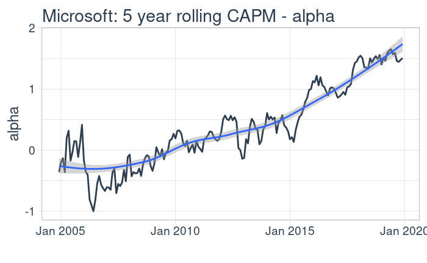

```r
#### plot alpha ####
create_alpha_plot <- function(joined_data_symbol, title) {
  filter(joined_data_symbol, !is.na(alpha)) %>%
    ggplot(aes(x = date, y = alpha)) +
        geom_line(size = 1, color = palette_light()[[1]]) +
        geom_smooth() +
        labs(title = title, x = "") +
        theme_tq(base_size = 18)
}

create_alpha_plot(joined_data_msft, "Microsoft: 5 year rolling CAPM - alpha")
```

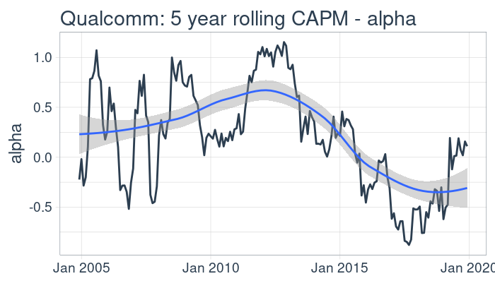

```r
create_alpha_plot(joined_data_qcom, "Qualcomm: 5 year rolling CAPM - alpha")
```

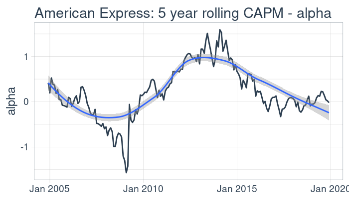

```r
create_alpha_plot(joined_data_axp, "American Express: 5 year rolling CAPM - alpha")
```

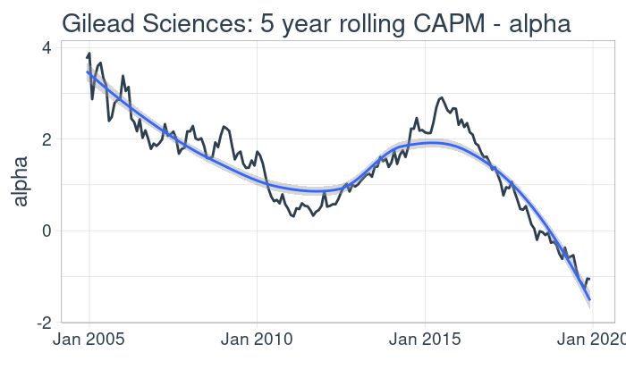

```r
create_alpha_plot(joined_data_gild, "Gilead Sciences: 5 year rolling CAPM - alpha")
```

Alpha is the performances of the investors compared to the market in %